# 02b - Longitudinal Analysis of Cannabis-related Temperatures (IP Administration)

Laura Saba

2022-01-13

## IP Administration Model - July

## Data Dictionary

[output not shown]

### Chronic effects of cannabis

For this analysis, I compared the temperature at during the ‘predose’ window across dosage groups using time in days as a continuous covariate. Data from dosing days and non-dosing days were included since we are only looking at the predose window.

**Two-Way ANOVA Results**

|  | Sum Sq | Mean Sq | NumDF | DenDF | F value | Pr(>F) |
| --- | --- | --- | --- | --- | --- | --- |
| dose | 0.0003292 | 0.0003292 | 1 | 1.418617 | 2.7894944 | 0.2844948 |
| study_day | 0.0062251 | 0.0062251 | 1 | 37.000000 | 52.7557048 | 0.0000000 |
| dose:study_day | 0.0000031 | 0.0000031 | 1 | 37.000000 | 0.0262312 | 0.8722182 |

**Comparing Slopes, i.e., study day trends, across dosage groups**

| dose | study_day.trend | SE | df | lower.CL | upper.CL |
| --- | --- | --- | --- | --- | --- |
| Control | -0.0032747 | 0.0007202 | 37 | -0.0047340 | -0.0018155 |
| High | -0.0031319 | 0.0005093 | 37 | -0.0041637 | -0.0021000 |

| contrast | estimate | SE | df | t.ratio | p.value |
| --- | --- | --- | --- | --- | --- |
| Control - High | -0.0001429 | 0.000882 | 37 | -0.1619605 | 0.8722182 |

**Model-based dose group estimates**

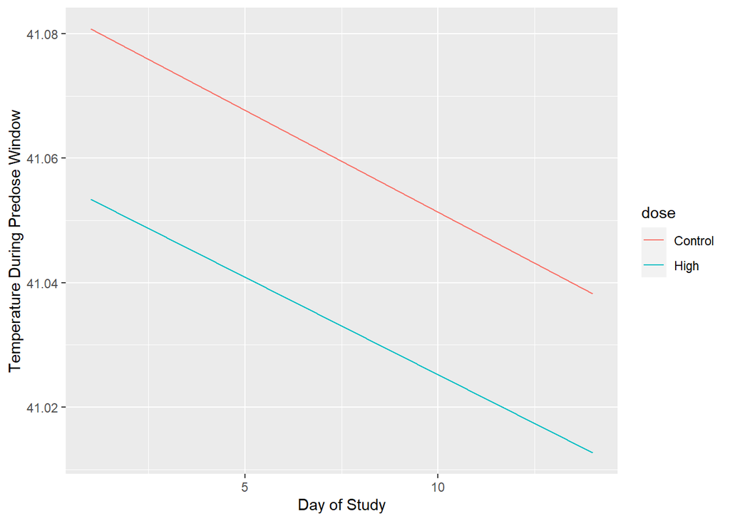

**Observed data**

Each line represents an individual mice.

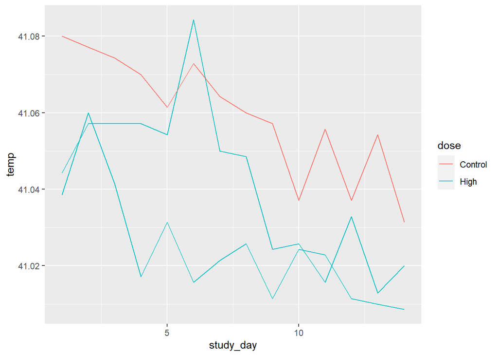

Based on my understanding of the study design, the 2 dosage groups should not differ in temperature at day 1 during the predose window because none of the animals would have received any cannabis prior to that time point.

Since this graphic made it look like the dosage groups differed at day 1, I tested that directly.

Omnibus p-value for dosage effect: 0.081

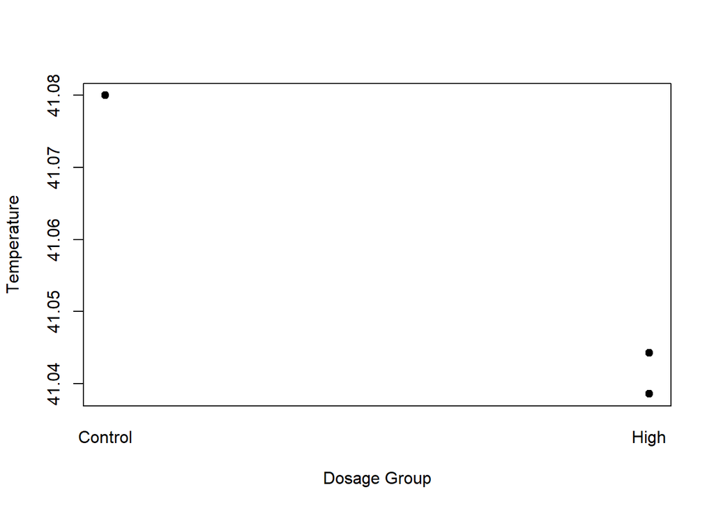

| contrast | estimate | SE | df | t.ratio | p.value |
| --- | --- | --- | --- | --- | --- |
| Control - High | 0.0385714 | 0.0049487 | 1 | 7.794237 | 0.0812345 |

## Acute Effects of Cannabis on Temperature

To examine the acute effects (i.e., within a treatment day) of cannabis, data points were limited to those collected during a ‘dose’ day.

### Initial Acute Effect of Cannabis on Temperature

First, the initial acute effects of cannabis were assessed by only focusing on changes in temperature across different windows of time on the first study day that mice were exposed to cannabis

**Two-Way ANOVA Results**

|  | Sum Sq | Mean Sq | NumDF | DenDF | F value | Pr(>F) |
| --- | --- | --- | --- | --- | --- | --- |
| dose | 0.0017403 | 0.0017403 | 1 | 0.972474 | 13.7286328 | 0.1733375 |
| time_window | 0.0009455 | 0.0001351 | 7 | 29.013771 | 1.0655797 | 0.4098024 |
| dose:time_window | 0.0002051 | 0.0000293 | 7 | 29.013771 | 0.2311722 | 0.9742878 |

There were no significant differences based on time window.

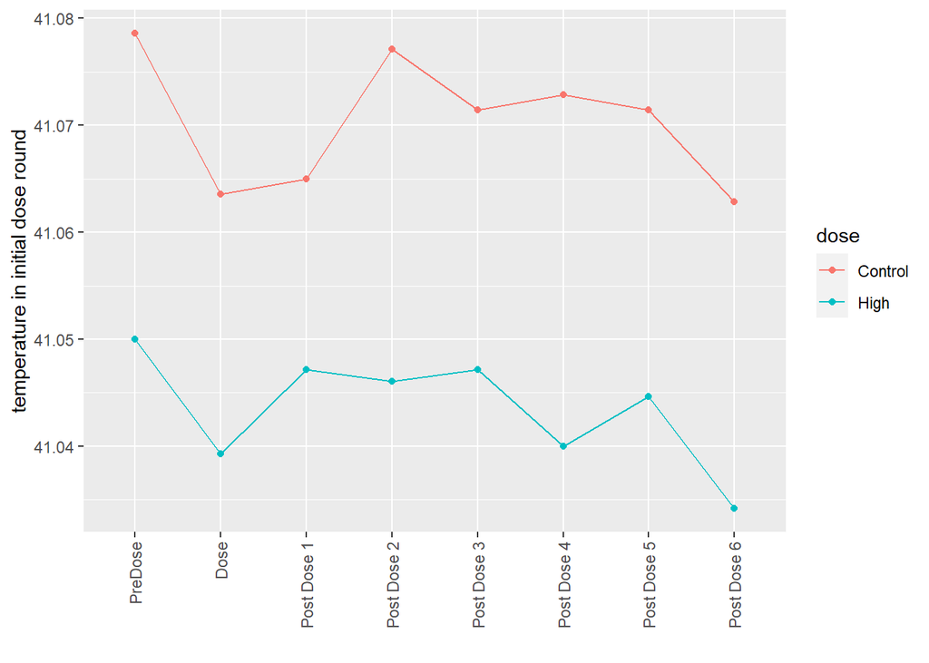

### Acute Effect of Cannabis on Temperature After Chronic Exposure to Cannabis

**Two-Way ANOVA Results**

|  | Sum Sq | Mean Sq | NumDF | DenDF | F value | Pr(>F) |
| --- | --- | --- | --- | --- | --- | --- |
| dose | 0.0006973 | 0.0006973 | 1 | 0.9999998 | 5.2396303 | 0.2622106 |
| time_window | 0.0007561 | 0.0001080 | 7 | 31.0000001 | 0.8116573 | 0.5844739 |
| dose:time_window | 0.0005757 | 0.0000822 | 7 | 31.0000001 | 0.6179564 | 0.7369058 |

There were no significant differences based on time window.

**Time Window Effect in Last Round of Dose Stratified by Dose**

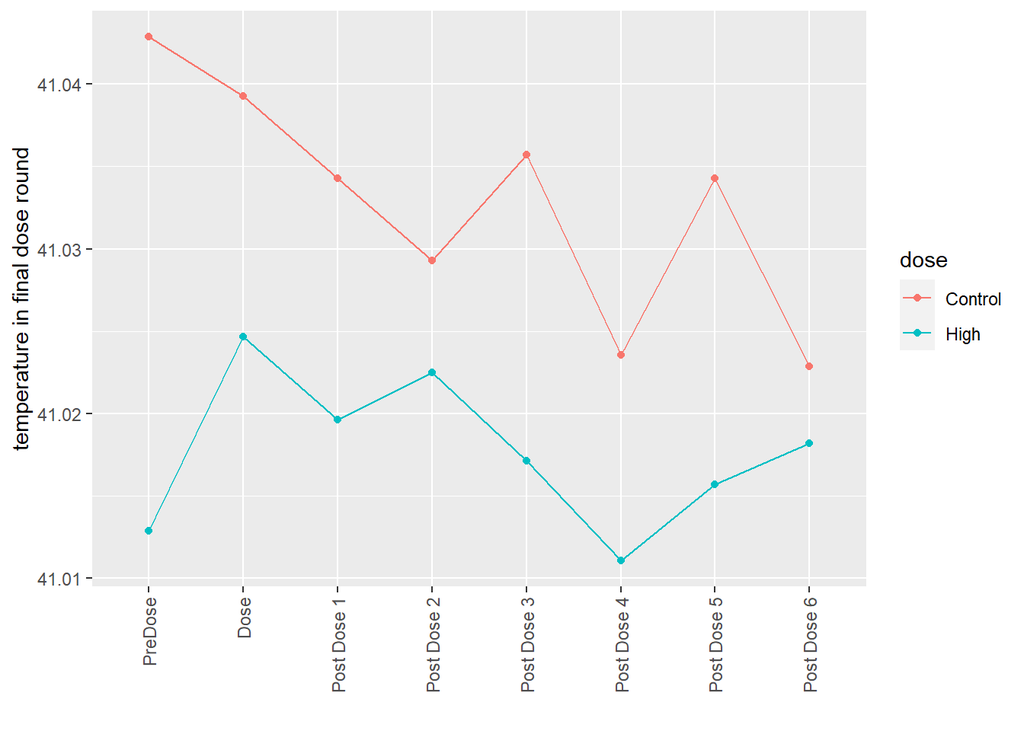

## IP Administration Model - January

Please note that there are no control mice for IP administration in the January experiment.

### Chronic effects of cannabis

For this analysis, I compared the temperature at during the ‘predose’ window across dosage groups using time in days as a continuous covariate. Data from dosing days and non-dosing days were included since we are only looking at the predose window.

**Two-Way ANOVA Results**

|  | Sum Sq | Mean Sq | NumDF | DenDF | F value | Pr(>F) |
| --- | --- | --- | --- | --- | --- | --- |
| dose | 1.268425 | 0.6342123 | 2 | 12.50017 | 5.449289 | 0.0198723 |
| study_day | 4.553008 | 4.5530083 | 1 | 52.00000 | 39.120432 | 0.0000001 |
| dose:study_day | 1.252931 | 0.6264653 | 2 | 52.00000 | 5.382726 | 0.0075050 |

**Comparing Slopes, i.e., study day trends, across dosage groups**

| dose | study_day.trend | SE | df | lower.CL | upper.CL |
| --- | --- | --- | --- | --- | --- |
| Low | -0.0271743 | 0.022643 | 52 | -0.0726109 | 0.0182622 |
| Medium | -0.0605821 | 0.016011 | 52 | -0.0927106 | -0.0284536 |
| High | -0.1125299 | 0.016011 | 52 | -0.1446584 | -0.0804014 |

| contrast | estimate | SE | df | t.ratio | p.value |
| --- | --- | --- | --- | --- | --- |
| Low - Medium | 0.0334078 | 0.0277319 | 52 | 1.204669 | 0.4558066 |
| Low - High | 0.0853556 | 0.0277319 | 52 | 3.077881 | 0.0091674 |
| Medium - High | 0.0519478 | 0.0226430 | 52 | 2.294206 | 0.0655045 |

**Model-based dose group estimates**

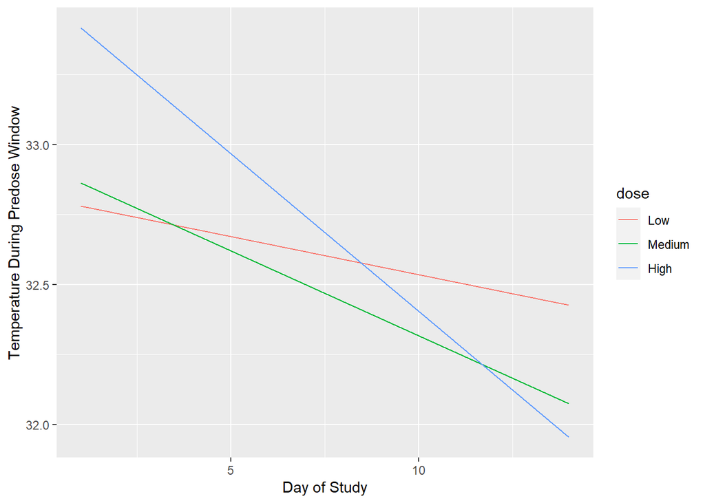

**Observed data**

Each line represents an individual mice.

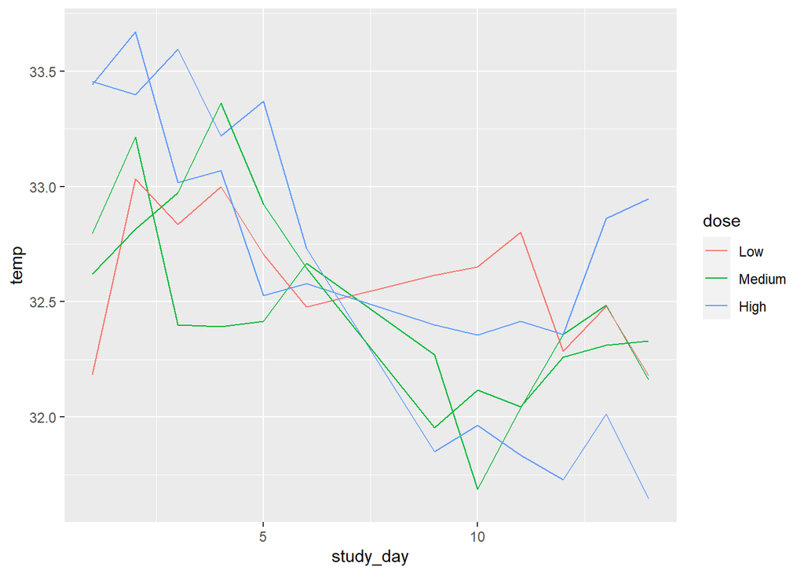

Based on my understanding of the study design, the 3 dosage groups should not differ in temperature at day 1 during the predose window because none of the animals would have received any cannabis prior to that time point.

Since this graphic made it look like the dosage groups differed at day 1, I tested that directly.

Omnibus p-value for dosage effect: 0.013

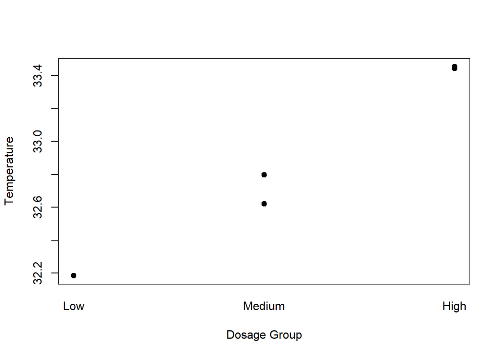

| contrast | estimate | SE | df | t.ratio | p.value |
| --- | --- | --- | --- | --- | --- |
| Low - Medium | -0.5242857 | 0.1087029 | 2 | -4.823106 | 0.0727858 |
| Low - High | -1.2642857 | 0.1087029 | 2 | -11.630650 | 0.0133246 |
| Medium - High | -0.7400000 | 0.0887556 | 2 | -8.337505 | 0.0256049 |

## Acute Effects of Cannabis on Temperature

To examine the acute effects (i.e., within a treatment day) of cannabis, data points were limited to those collected during a ‘dose’ day.

### Initial Acute Effect of Cannabis on Temperature

First, the initial acute effects of cannabis were assessed by only focusing on changes in temperature across different windows of time on the first study day that mice were exposed to cannabis

**Two-Way ANOVA Results**

|  | Sum Sq | Mean Sq | NumDF | DenDF | F value | Pr(>F) |
| --- | --- | --- | --- | --- | --- | --- |
| dose | 11.26076 | 5.6303782 | 2 | 2 | 30.928498 | 0.0313200 |
| time_window | 11.07705 | 1.5824353 | 7 | 54 | 8.692550 | 0.0000004 |
| dose:time_window | 2.55176 | 0.1822686 | 14 | 54 | 1.001228 | 0.4655373 |

There were significant main effects of both dose and time window, but the interaction effect was not significant.

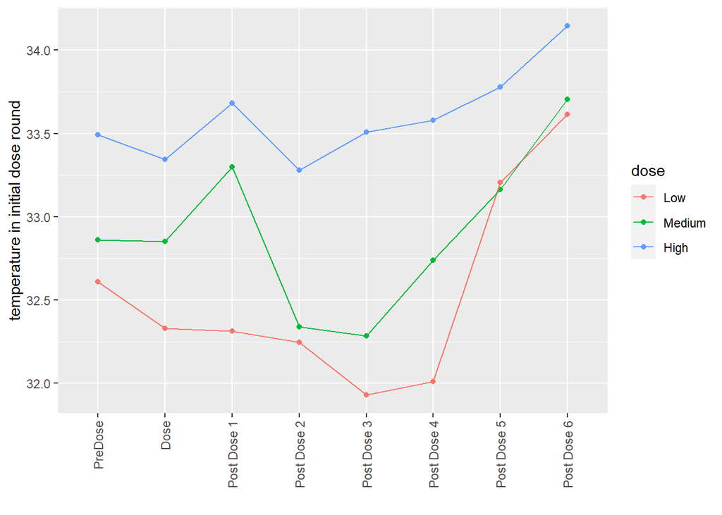

| contrast | dose | estimate | SE | df | t.ratio | p.value |
| --- | --- | --- | --- | --- | --- | --- |
| Dose - PreDose | Low | -0.2779464 | 0.4266673 | 54 | -0.6514360 | 0.5175280 |
| Post Dose 1 - PreDose | Low | -0.2942857 | 0.4266673 | 54 | -0.6897311 | 0.4933169 |
| Post Dose 2 - PreDose | Low | -0.3628571 | 0.4266673 | 54 | -0.8504451 | 0.3988329 |
| Post Dose 3 - PreDose | Low | -0.6792857 | 0.4266673 | 54 | -1.5920735 | 0.1172058 |
| Post Dose 4 - PreDose | Low | -0.5992857 | 0.4266673 | 54 | -1.4045738 | 0.1658742 |
| Post Dose 5 - PreDose | Low | 0.5978571 | 0.4266673 | 54 | 1.4012256 | 0.1668678 |
| Post Dose 6 - PreDose | Low | 1.0064286 | 0.4266673 | 54 | 2.3588134 | 0.0219817 |

| contrast | dose | estimate | SE | df | t.ratio | p.value |
| --- | --- | --- | --- | --- | --- | --- |
| Dose - PreDose | Medium | -0.0104018 | 0.3016993 | 54 | -0.0344773 | 0.9726237 |
| Post Dose 1 - PreDose | Medium | 0.4367857 | 0.3016993 | 54 | 1.4477516 | 0.1534678 |
| Post Dose 2 - PreDose | Medium | -0.5232143 | 0.3016993 | 54 | -1.7342241 | 0.0885842 |
| Post Dose 3 - PreDose | Medium | -0.5760714 | 0.3016993 | 54 | -1.9094222 | 0.0615265 |
| Post Dose 4 - PreDose | Medium | -0.1221429 | 0.3016993 | 54 | -0.4048496 | 0.6871874 |
| Post Dose 5 - PreDose | Medium | 0.3025000 | 0.3016993 | 54 | 1.0026538 | 0.3204998 |
| Post Dose 6 - PreDose | Medium | 0.8439286 | 0.3016993 | 54 | 2.7972502 | 0.0071275 |

| contrast | dose | estimate | SE | df | t.ratio | p.value |
| --- | --- | --- | --- | --- | --- | --- |
| Dose - PreDose | High | -0.1459375 | 0.3016993 | 54 | -0.4837183 | 0.6305416 |
| Post Dose 1 - PreDose | High | 0.1917857 | 0.3016993 | 54 | 0.6356849 | 0.5276668 |
| Post Dose 2 - PreDose | High | -0.2128571 | 0.3016993 | 54 | -0.7055274 | 0.4835146 |
| Post Dose 3 - PreDose | High | 0.0171429 | 0.3016993 | 54 | 0.0568210 | 0.9548975 |
| Post Dose 4 - PreDose | High | 0.0882143 | 0.3016993 | 54 | 0.2923914 | 0.7711079 |
| Post Dose 5 - PreDose | High | 0.2878571 | 0.3016993 | 54 | 0.9541192 | 0.3442750 |
| Post Dose 6 - PreDose | High | 0.6539286 | 0.3016993 | 54 | 2.1674842 | 0.0346259 |

### Acute Effect of Cannabis on Temperature After Chronic Exposure to Cannabis

**Two-Way ANOVA Results**

|  | Sum Sq | Mean Sq | NumDF | DenDF | F value | Pr(>F) |
| --- | --- | --- | --- | --- | --- | --- |
| dose | 0.0209838 | 0.0104919 | 2 | 2 | 0.1066663 | 0.9036148 |
| time_window | 10.6091850 | 1.5155979 | 7 | 54 | 15.4083961 | 0.0000000 |
| dose:time_window | 0.7242059 | 0.0517290 | 14 | 54 | 0.5259052 | 0.9070458 |

The two-way ANOVA results suggest that there are is a significant difference across time windows and that difference is consistent across dosage group.

**Time Window Effect in Last Round of Dose Stratified by Dose**

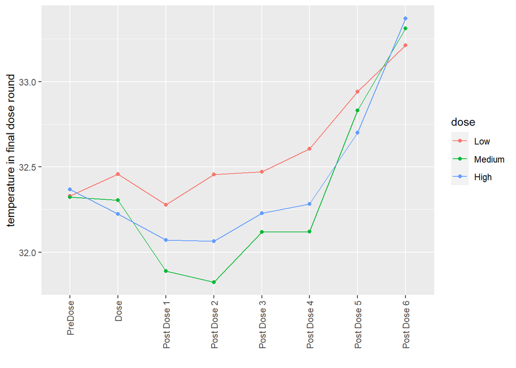

| contrast | dose | estimate | SE | df | t.ratio | p.value |
| --- | --- | --- | --- | --- | --- | --- |
| Dose - PreDose | Low | 0.1285714 | 0.3136269 | 54 | 0.4099503 | 0.6834643 |
| Post Dose 1 - PreDose | Low | -0.0507143 | 0.3136269 | 54 | -0.1617026 | 0.8721436 |
| Post Dose 2 - PreDose | Low | 0.1250000 | 0.3136269 | 54 | 0.3985628 | 0.6917870 |
| Post Dose 3 - PreDose | Low | 0.1421429 | 0.3136269 | 54 | 0.4532228 | 0.6522043 |
| Post Dose 4 - PreDose | Low | 0.2764286 | 0.3136269 | 54 | 0.8813931 | 0.3820114 |
| Post Dose 5 - PreDose | Low | 0.6114286 | 0.3136269 | 54 | 1.9495414 | 0.0564319 |
| Post Dose 6 - PreDose | Low | 0.8835714 | 0.3136269 | 54 | 2.8172695 | 0.0067521 |

| contrast | dose | estimate | SE | df | t.ratio | p.value |
| --- | --- | --- | --- | --- | --- | --- |
| Dose - PreDose | Medium | -0.0167857 | 0.2217677 | 54 | -0.0756905 | 0.9399450 |
| Post Dose 1 - PreDose | Medium | -0.4325000 | 0.2217677 | 54 | -1.9502390 | 0.0563466 |
| Post Dose 2 - PreDose | Medium | -0.4982143 | 0.2217677 | 54 | -2.2465594 | 0.0287792 |
| Post Dose 3 - PreDose | Medium | -0.2032143 | 0.2217677 | 54 | -0.9163385 | 0.3635636 |
| Post Dose 4 - PreDose | Medium | -0.2017857 | 0.2217677 | 54 | -0.9098968 | 0.3669205 |
| Post Dose 5 - PreDose | Medium | 0.5075000 | 0.2217677 | 54 | 2.2884307 | 0.0260518 |
| Post Dose 6 - PreDose | Medium | 0.9892857 | 0.2217677 | 54 | 4.4609100 | 0.0000418 |

| contrast | dose | estimate | SE | df | t.ratio | p.value |
| --- | --- | --- | --- | --- | --- | --- |
| Dose - PreDose | High | -0.1421429 | 0.2217677 | 54 | -0.6409539 | 0.5242636 |
| Post Dose 1 - PreDose | High | -0.2957143 | 0.2217677 | 54 | -1.3334417 | 0.1879847 |
| Post Dose 2 - PreDose | High | -0.3017857 | 0.2217677 | 54 | -1.3608191 | 0.1792235 |
| Post Dose 3 - PreDose | High | -0.1382143 | 0.2217677 | 54 | -0.6232390 | 0.5357510 |
| Post Dose 4 - PreDose | High | -0.0839286 | 0.2217677 | 54 | -0.3784526 | 0.7065782 |
| Post Dose 5 - PreDose | High | 0.3328571 | 0.2217677 | 54 | 1.5009271 | 0.1391993 |
| Post Dose 6 - PreDose | High | 1.0021429 | 0.2217677 | 54 | 4.5188857 | 0.0000343 |